# R Notebook

```r
library(tidyverse)
library(infer)
msleep <- msleep
```

# 1.1 Hypothesis testing - practical

## Question 1

Explore the dataset and familiarise yourself with it.

```r
glimpse(msleep)
```

```
Rows: 83
Columns: 11
$ name         <chr> "Cheetah", "Owl monkey", "Mountain beaver", "Greater short-tailed shrew", "Cow", "Three-toed s…
$ genus        <chr> "Acinonyx", "Aotus", "Aplodontia", "Blarina", "Bos", "Bradypus", "Callorhinus", "Calomys", "Ca…
$ vore         <chr> "carni", "omni", "herbi", "omni", "herbi", "herbi", "carni", NA, "carni", "herbi", "herbi", "h…
$ order        <chr> "Carnivora", "Primates", "Rodentia", "Soricomorpha", "Artiodactyla", "Pilosa", "Carnivora", "R…
$ conservation <chr> "lc", NA, "nt", "lc", "domesticated", NA, "vu", NA, "domesticated", "lc", "lc", "domesticated"…
$ sleep_total  <dbl> 12.1, 17.0, 14.4, 14.9, 4.0, 14.4, 8.7, 7.0, 10.1, 3.0, 5.3, 9.4, 10.0, 12.5, 10.3, 8.3, 9.1, …
$ sleep_rem    <dbl> NA, 1.8, 2.4, 2.3, 0.7, 2.2, 1.4, NA, 2.9, NA, 0.6, 0.8, 0.7, 1.5, 2.2, 2.0, 1.4, 3.1, 0.5, 4.…
$ sleep_cycle  <dbl> NA, NA, NA, 0.1333333, 0.6666667, 0.7666667, 0.3833333, NA, 0.3333333, NA, NA, 0.2166667, NA, …
$ awake        <dbl> 11.90, 7.00, 9.60, 9.10, 20.00, 9.60, 15.30, 17.00, 13.90, 21.00, 18.70, 14.60, 14.00, 11.50, …
$ brainwt      <dbl> NA, 0.01550, NA, 0.00029, 0.42300, NA, NA, NA, 0.07000, 0.09820, 0.11500, 0.00550, NA, 0.00640…
$ bodywt       <dbl> 50.000, 0.480, 1.350, 0.019, 600.000, 3.850, 20.490, 0.045, 14.000, 14.800, 33.500, 0.728, 4.7…
```

## Question 2

Jabberwockies sleep for around 7 hours a night, on average. Perform an appropriate statistical test to determine whether the mean sleep_total in the sampled population of animal types differs from the typical value for jabberwockies.

1 - We are comparing the mean from the msleep sample against the specified value (j_sleep_mean = 7 hours). This is a one-sample mean test.

2 - Set a significance level and define hypothesis

alpha: 0.05

H0: average_sleep_animals - 7 == 0

Ha: average_sleep_animals - 7 != 0

3 - Calculate observed statistic (mean_sleep)

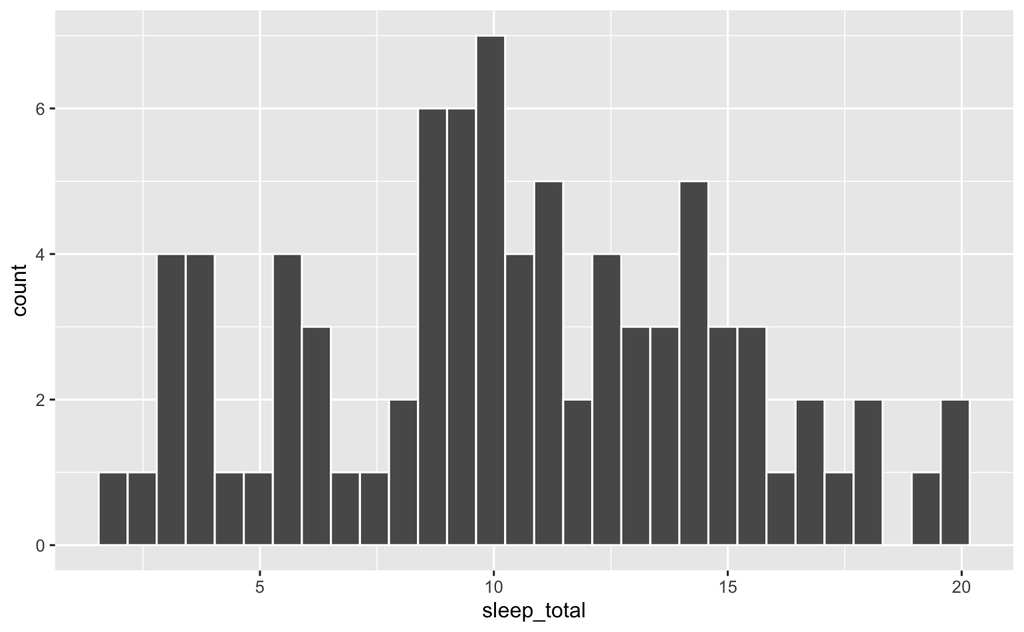

```r
msleep %>%
  ggplot(aes(x = sleep_total)) +
  geom_histogram(col = "white")
```

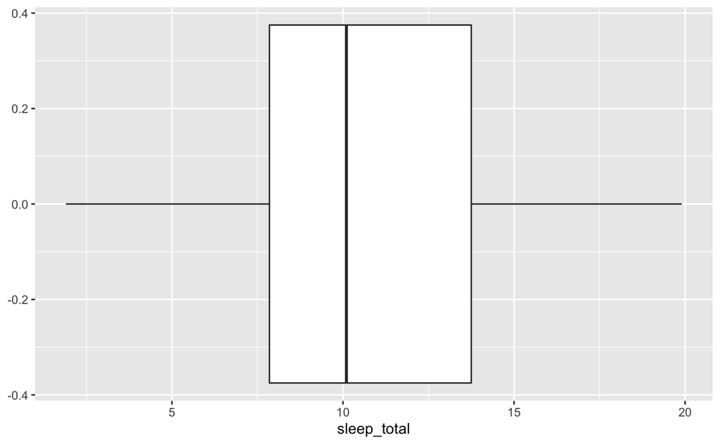

| mean_sleep |
| --- |
| 10.43373 |

The mean_sleep of our sample is 10.43 hours

4 - Simulate the situation where the null hypothesis is TRUE, by generating a null distribution

```r
null_distribution
```

```
Response: sleep_total (numeric)
Null Hypothesis: point
```

[output not shown]

[output cut: 990 more lines]

5 - Visualise the null distribution and overlay the observed statistic

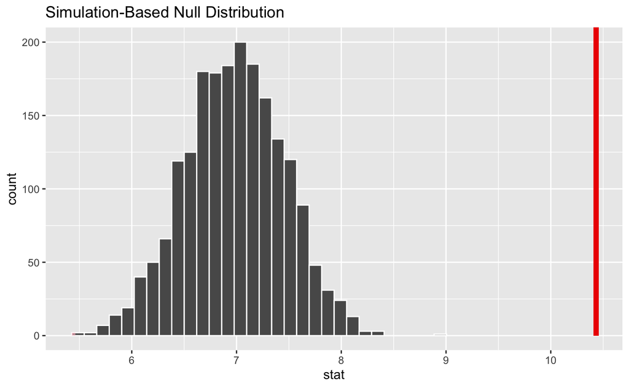

```r
null_distribution %>%
  visualise(bins = 30) +
  shade_p_value(
    obs_stat = observed_stat$mean_sleep,
    direction = "both")
```

6 - Get p-value

```r
p_value <- null_distribution %>%
  get_p_value(
    obs_stat = observed_stat$mean_sleep,
    direction = "both"
  )
format.pval(p_value)
```

```
[1] "< 2.22e-16"
```

```r
format.pval(p_value)
```

```
[1] "< 2.22e-16"
```

7 - Conclusions: With a p-value very close to zero and less than our significance level of 0.05, we may reject the null hypothesis in favour of our alternative hypothesis: the mean sleep_total in the sampled population of animal types differs statistically significantly from the typical value for jabberwockies.

## Question 3

Perform an appropriate statistical test to determine whether omnivores sleep for significantly longer than herbivores, on average.

1 - We are comparing the mean of omnivores’ sleep against herbivores’. This is a two-means independent samples test.

2 - Set a significance level and define hypothesis

alpha: 0.05

H0: average_sleep_omni - average_sleep_herbi <= 0

Ha: average_sleep_omni - average_sleep_herbi > 0

3 - Calculate observed statistic (mean_sleep_omni, mean_sleep_herbi)

| vore | sleep_total |
| --- | --- |
| omni | 17.0 |
| herbi | 14.4 |
| omni | 14.9 |
| herbi | 4.0 |
| herbi | 14.4 |
| herbi | 3.0 |
| herbi | 5.3 |
| herbi | 9.4 |
| omni | 10.0 |
| herbi | 12.5 |

[output cut: 42 more lines]

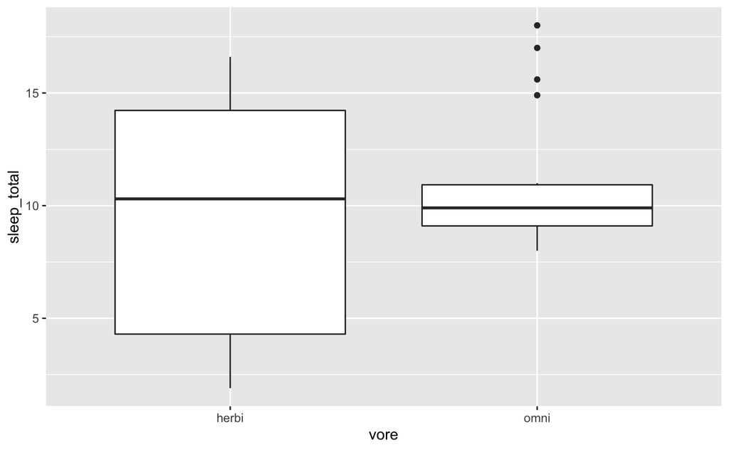

```r
omni_herbi %>%
  ggplot(aes(x = vore, y = sleep_total)) +
  geom_boxplot()
```

```r
omni_herbi %>%
  group_by(vore) %>%
  summarise(mean_sleep = mean(sleep_total))
```

| vore | mean_sleep |
| --- | --- |
| herbi | 9.509375 |
| omni | 10.925000 |

```r
observed_stat
```

```
Response: sleep_total (numeric)
Explanatory: vore (factor)
```

| stat |
| --- |
| 1.415625 |

4 - Simulate the situation where the null hypothesis is TRUE, by generating a null distribution

```r
null_distribution
```

```
Response: sleep_total (numeric)
Explanatory: vore (factor)
Null Hypothesis: independence
```

| replicate | stat |
| --- | --- |
| 1 | -0.721250 |
| 2 | -0.599375 |
| 3 | -0.802500 |
| 4 | -1.403750 |
| 5 | -1.379375 |
| 6 | 1.578125 |
| 7 | -2.175625 |
| 8 | 0.765625 |
| 9 | 0.521875 |
| 10 | 1.147500 |

[output cut: 990 more lines]

5 - Visualise the null distribution and overlay the observed statistic

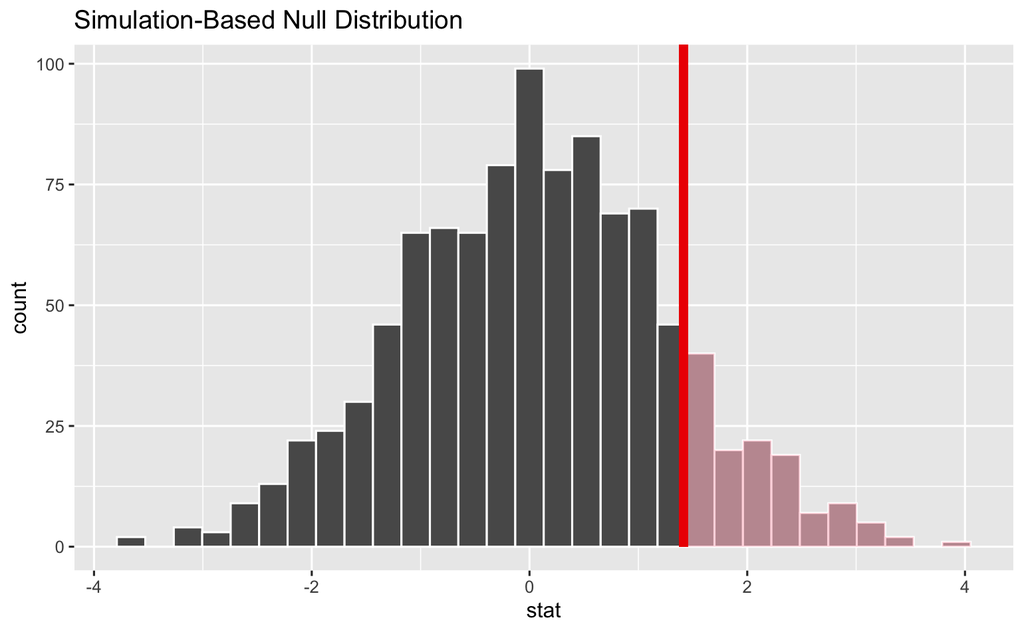

```r
null_distribution %>%
  visualise(bins = 30) +
  shade_p_value(
    obs_stat = observed_stat$stat,
    direction = "right"
    )
```

6 - Get p-value

| p_value |
| --- |
| 0.128 |

7 - Conclusions: With a p-value of 0.128, grater than our significance level of 0.05, we fail to reject the null hypothesis in favour of our alternative hypothesis. The mean omni_sleep in the sampled population does not differ statistically significantly from the mean herbi_sleep.

## Question 4

Perform an appropriate statistical test to determine whether the proportion of domesticated animal types in the population of animal types is greater than 5%. Hint Think about creating an is_domesticated variable for the analysis.

1 - We are comparing the proportion of domesticated animal type over the whole population of our sample. This is a one-sample proportion test.

2 - Set a significance level and define hypothesis

alpha: 0.05

H0: prop_domesticated <= 0.05

Ha: prop_domesticated > 0.05

3 - Calculate observed statistic (prop_domesticated)

```r
print(msleep %>%
        group_by(conservation) %>%
        summarise(count = n()))
```

| conservation | count |
| --- | --- |
| cd | 2 |
| domesticated | 10 |
| en | 4 |
| lc | 27 |
| nt | 4 |
| vu | 7 |
| NA | 29 |

There are 29 NA over 83 observations; this is a significant proportion of the sample and will affect the following calculations when dropped.

```r
msleep <- msleep %>%
  filter(!is.na(conservation))
```

| prop_domesticated |
| --- |
| 0.1851852 |

4 - Simulate the situation where the null hypothesis is TRUE, by generating a null distribution

```r
domesticated <- msleep %>%
  mutate(is_domesticated = if_else(
    conservation == "domesticated", TRUE,
    FALSE)) %>%
  select(name, is_domesticated)

domesticated
```

| name | is_domesticated |
| --- | --- |
| Cheetah | FALSE |
| Mountain beaver | FALSE |
| Greater short-tailed shrew | FALSE |
| Cow | TRUE |
| Northern fur seal | FALSE |
| Dog | TRUE |
| Roe deer | FALSE |
| Goat | FALSE |
| Guinea pig | TRUE |
| Grivet | FALSE |

[output cut: 44 more lines]

```r
null_distribution
```

```
Response: is_domesticated (factor)
Null Hypothesis: point
```

[output not shown]

[output cut: 990 more lines]

5 - Visualise the null distribution and overlay the observed statistic

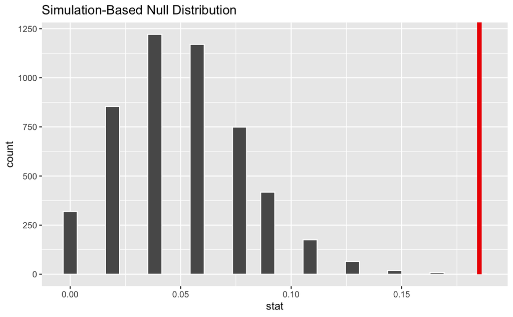

```r
null_distribution %>%
  visualise(bins = 30) +
  shade_p_value(obs_stat = observed_stat$prop_domesticated,
                direction = "right")
```

6 - Get p-value

```r
p_value <- null_distribution %>%
  get_p_value(obs_stat = observed_stat, direction = "right")

p_value
```

| p_value |
| --- |
| 2e-04 |

7 - Conclusions: With a p-value very close to zero and less than our significance level of 0.05, we may reject the null hypothesis in favour of our alternative hypothesis: the proportion of domesticated animal types in the population is statistically significantly greater than 5%.

# 1.2 Hypothesis testing - Defining the Hypothesis

For the following three business problems write out:

- What kind of test you would use
- H0 and Ha in both mathematical notation and in words.
- Also state the method you would use to generate the null distribution (bootstrap, permutation or draw).

## Question 1

You work for a independent coffee shop. The boss tells you that she thinks that around 40% of people in the town (population 30,000) know of the coffee shop, but you are skeptical of the estimate. You conduct a random survey of 200 people in the town, asking if respondents are aware of your coffee shop. You want to use the sample to test the hypothesis that 40% or more of the town’s population have heard of the coffee shop.

- We are comparing the proportion of people who have heard of the coffee shop over the whole population of our sample. This is a one-sample proportion test.
- Define hypothesis

H0: 40% of the population know of the coffee shop H0: prop_know_shop = 0.4 Ha: more than 40% of the population know of the coffee shop Ha: prop_know_shop > 0.4

- Generation of null distribution

As we are testing a proportion, we draw the null distribution (not relying on our sample data).

## Question 2

You work for a website design company and have performed an A/B test on the position of a banner on a website promoting a particular item. You selected five days at random last month and then randomly selected 200 of each sampled day’s users into group A and another 200 of that day’s users into group B. Group A continued to be shown the banner at the right hand side of the webpage (its usual position) while group B was shown the banner at the top of the page. You monitored each sampled user’s interactions with the website, in particular the ‘click through rate’ (CTR) on the banner, i.e. what proportion of sampled users clicked on the banner. You want to use the sampled data to test the hypothesis that website users overall are more likely to click on the banner if positioned at the top of the page

- We are comparing the proportion of people who are more likely to click on the banner if positioned at the top of the page, against the proportion of people who are more likely to click on the banner if positioned at its usual position. This is a two-proportion independent samples test.
- Define hypothesis

H0: the CTR tested in group B is the same as or lower than the CTR tested in group A H0: CTR_B - CTR_A <= 0 Ha: the CTR tested in group B is higher than the CTR tested in group A Ha: CTR_B - CTR_A > 0

- Generation of null distribution

As we are testing a proportion in 2 independent groups, it wouldn’t matter how we split the observations into group A or group B, so we permute our null distribution (randomly shuffle).

## Question 3

You work as an analyst for a car manufacturing company - they have specific standards they must meet for standards and regulation purposes. You have been asked to check the quality control of the manufacture of a particular car part. You have been given data on a sample of 200 parts produced over the period of a week (the sampled parts were pulled at random from the production line and measured: the factory produced a lot more than 200 parts that week). The specification of the part stipulates a width of 145mm, and the manufacturing process is said to have ‘drifted’ if the mean width of parts differs significantly from 145mm. You want to use the sampled measurements to test whether the process overall has drifted.

We are comparing the mean width of car parts from the provided sample against the specified value (width = 145 mm). This is a one-sample mean test.

- Define hypothesis

H0: the car part width mean of the sample equals 145mm H0: mean_width_car_part == 145mm Ha: the car part width mean of the sample differs from 145mm Ha: mean_width_car_part != 145mm

- Generation of null distribution

As we are testing a mean, we bootstrap (sample with replacement) from our original sample to create the null distribution.

# 1.3 Hypothesis Testing - Interpreting the results

## Question 1

Coffee shop problem. Significance level: 0.05, calculated p-value: 0.07

As our p-value: 0.07 is greater than our significance level alpha: 0.05, we lack sufficient evidence to reject H0, so we fail to reject H0 in favour of Ha. Based on our sample, we do not have enough evidence that the proportion of the population that knows of the coffee shop, is statistically significantly greater than the null value (40%).

## Question 2

Website company problem. Significance level: 0.01, p-value: 0.006

As our p-value: 0.006 is smaller than our significance level alpha: 0.01, we have sufficient evidence to reject H0 in favour of Ha. We found enough evidence in the sample to suggest that CTR_B is statistically significantly greater than CTR_A.

## Question 3

Manufacturing company problem. Significance level: 0.05, p-value: 0.55

As our p-value: 0.55 is greater than our significance level alpha: 0.05, we lack sufficient evidence to reject H0, so we fail to reject H0 in favour of Ha. Based on our sample, we do not have enough evidence that the mean of the width of car parts is statistically significantly different from the null value (145mm).